[Cancer Systems Biology](https://jiantaoshi.github.io/index.html)

[Publications](https://jiantaoshi.github.io/Publications.html) [Software](https://jiantaoshi.github.io/Software.html) [Patents](https://jiantaoshi.github.io/Patents.html) [People](https://jiantaoshi.github.io/People.html) [Notebook](https://jiantaoshi.github.io/Notebook.html) [Careers](https://jiantaoshi.github.io/Careers.html)

# Universal Early Cancer Diagnostics

# Intruduction

Recent research demonstrates that circulating tumor DNA (ctDNA) has the potential to revolutionize screening, diagnosis, and treatment of cancer by enabling a non-invasive liquid biopsy. ctDNA fragments bearing cancer-specific methylation patterns have been investigated as feasible biomarkers in cancers because they can be easily discriminated from those of normal cells; however, currently there are few validated methylation markers available, with notable exceptions such as SEPT9 in colorectal cancer. DNA methylation profiling offers several advantages over somatic mutation analysis for cancer detection, including a broader distribution across hundreds of target loci in the disease state and multiple altered CpG sites within each targeted genomic region and thus higher clinical sensitivity and dynamic range. A recent study identified 10 CpG sites for diagnosis and prognosis of hepatocellular carcinoma using DNA methylation of cfDNA. However, the application of liquid biopsies to other cancer types remains a challenge.

Our approach is broadly built on the observation that epigenetic restriction of extraembryonic lineages mirrors the somatic transition to cancer [[Smith and Shi, Nature 2017]](https://jiantaoshi.github.io/Publications/nature23891.pdf). We systematically compared DNA methylation profiles of extraembryonic ectoderm (ExE) and epiblast (Epi), and found a signature of CpG Islands (CGI) that are hyper-methylated in ExE (ExE hyper). De novo methylation of CGIs is a general feature of in vitro tissue culture, numerous cancer cell lines, and primary tumors, suggesting that somatic cells remain vulnerable to acquiring this state. To investigate a possible link between this early developmental program and the reemergence of this landscape in cancer, we mapped orthologous CGIs from mouse to human and directly compared ExE hyper CGIs across patient-matched DNA methylation profiles acquired as part of The Cancer Genome Atlas (TCGA) project, as well as other samples profiled by the ENCODE/Roadmap Epigenomics Project. Of the 15 TCGA tumor types with sufficient numbers of patient-matched normal biopsied tissues, we found that 14 significantly methylate ExE hyper CGIs (Fig. 1). The signal is surprisingly robust, such that the ExE hyper CGI set segregates tumor and normal tissue when measured as a feature across patients. Moreover, ExE and tumor methylated CGIs significantly overlap – 84% are shared with at least one other cancer type – and are conserved across cancer types. Furthermore, ExE hyper methylation seems to be an early event during disease progression and can be found in pre-cancer stages. For instance, this signature can be found in ductal carcinoma in situ (DCIS) and monoclonal B-cell lymphocytosis (MBL), which are pre-cancer stages of breast cancer and Chronic Lymphocytic Leukemia (CLL), respectively (Fig. 1). We believe that our signature is sufficiently sensitive to detect most cancer types and represents a universal signature for for cancer diagnostics.

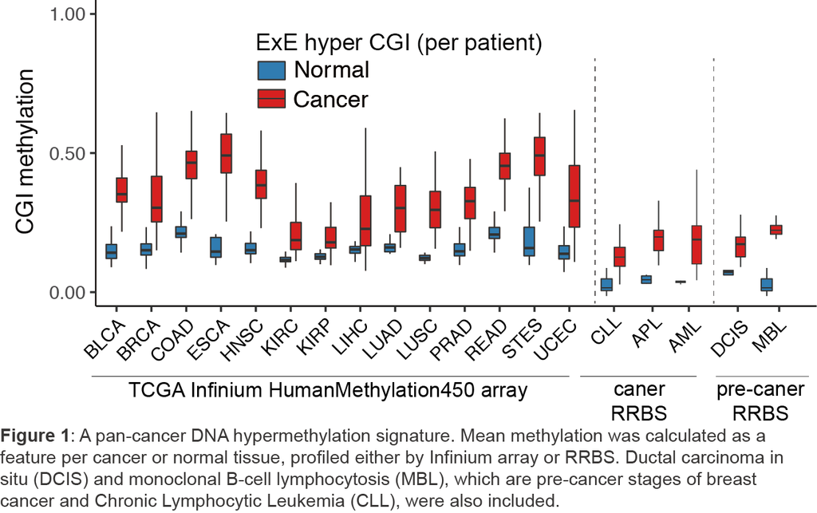

# CpG islands protected by this patent

We have filed a list of CpG Islands that are hypermethylated in either mouse ExE or human placenta. [[CGIs for Universal Early Cancer Diagnostics]](https://jiantaoshi.github.io/Patents/ExE_hPlacenta_CGI.xlsx). It’s publicly available through [Google Patents](https://patents.google.com/patent/US20200109456A1/en).

# References

Shanghai Institute of Biochemistry and Cell Biology, Center for Excellence in Molecular Cell Science, CAS